# DynafluxR - Supplementary information

This notebook performs all computational analyses detailed in:

> **Estimating flux dynamics from metabolite concentrations time courses with dynafluxr.**

> S. Sokol, S. Dubiley, P. Rouan, C. Charlier, G. Lippens, P. Millard

This R Markdown notebook is available at https://github.com/MetaSys-LISBP/DynafluxR_notebook under a GPLv3 License, and DynafluxR is available at https://github.com/MetaSys-LISBP/dynafluxr.

Author: Pierre Millard (pierre.millard@insa-toulouse.fr)

Copyright INRAE, 2025

# 1. Prepare environment

Load DynafluxR and other required packages.

```r
library(dynafluxr)
```

```r
library(CoRC)
library(RColorBrewer)
library(stringr)
library(vioplot)
# color generator
col_pal <- brewer.pal(n=12, name='Paired')[c(2,4,6,8,10,12)]
col_pal_alpha <- paste(col_pal, "55", sep="")

col_8 <- c("#008751", "#1D2B53", "#29ADFF", "#FFA300", "#83769C", "#FF77A8", "#AB5236", "#E31A1C")
col_8_alpha <- paste(col_8, "55", sep="")

col_6 <- c("#F16745", "#7BC8A4", "#93648D", "#4CC3D9", "#404040", "#FFC65D")
col_6_alpha <- paste(col_6, "55", sep="")
```

Set path.

```r
# get current directory
wd <- getwd()

# change the path if needed
#wd <- "~/GIT/dynafluxr/sup_data"
```

# 2. Example 1: Synthetic dataset

Set paths.

```r
example1_dir <- file.path(wd, "toy_model")
model_dir <- file.path(example1_dir, "model")
results_dir <- file.path(example1_dir, "results")
tmp_dir <- file.path(results_dir, "tmp")
```

## 2.1. Simulation of the dataset

Simulate time-course fluxes and metabolite concentrations (20 equally time points) using a kinetic model and COPASI.

```r
# load kinetic model in COPASI
loadModel(file.path(model_dir, "model.cps"))
# run time course simulations (20 time points)
setTimeCourseSettings(intervals=19)
simulations <- runTimeCourse()

# save time-course concentrations
concentrations <- simulations$result[,1:12]
write.table(concentrations, file.path(results_dir, "sim_data.txt"), row.names=FALSE, sep="\t", quote=FALSE)
```

## 2.2. Dynamic flux calculation

Calculate fluxes from true (simulated) data with DynafluxR (using default values for all parameters).

```r
startTime <- Sys.time()

# run flux calculation
res <- cli(c("-m", file.path(results_dir, "sim_data.txt"),
             "-s", file.path(example1_dir, "network.txt")))

endTime <- Sys.time()
print(endTime - startTime)
```

```
#> Time difference of 0.6572151 secs
```

Plot true vs fitted metabolite dynamics (Figure 2B).

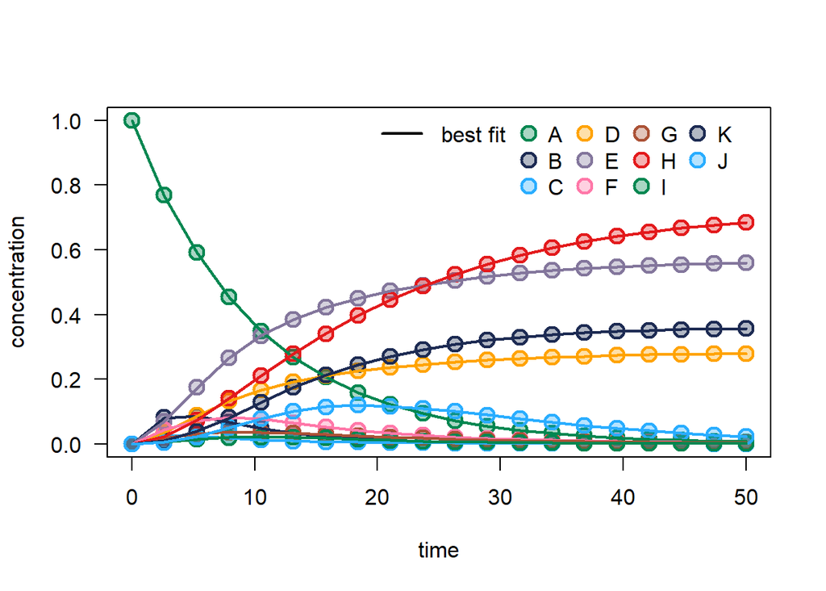

```r
# best fit
x_sim <- res$tp
y_sim <- res$isp(res$tp)

# simulated data
x <- simulations$result[,1]
y <- simulations$result[,colnames(y_sim)]

# plot simulated vs fitted data
matplot(x=x, y=y, type="p", pch=21, cex=1.5, lwd=2, col=col_8, bg=col_8_alpha, las=1, ylab="concentration", xlab="time")
matlines(x=x_sim, y=y_sim, lwd=2, lty=1, col=col_8)
legend("topright", inset=c(0.04, 0), legend=colnames(y), col=col_8, pch=21, pt.bg=col_8_alpha, pt.cex=1.5, pt.lwd=2, bty="n", ncol=4)

# add legend
legend("top", inset=c(-0.08, 0), legend="best fit", col="black", lwd=2, bty="n")

# add confidence intervals
y_sim_sd_p <- res$rsp(res$tpp)
y_sim_sd_m <- res$rsp(res$tpp)
for (i in seq(ncol(y_sim))){
  polygon(x=c(res$tpp, rev(res$tpp)), y=c((y_sim_sd_p[,i]), rev(y_sim_sd_m[,i])),
          col=col_8_alpha, border=NA)
}
```

Mean error on metabolite concentrations.

```r
mean_err_conc <- mean(as.matrix(abs(y-y_sim)))

mean_err_conc
```

```
#> [1] 0.0002892088
```

Plot true vs fitted flux dynamics.

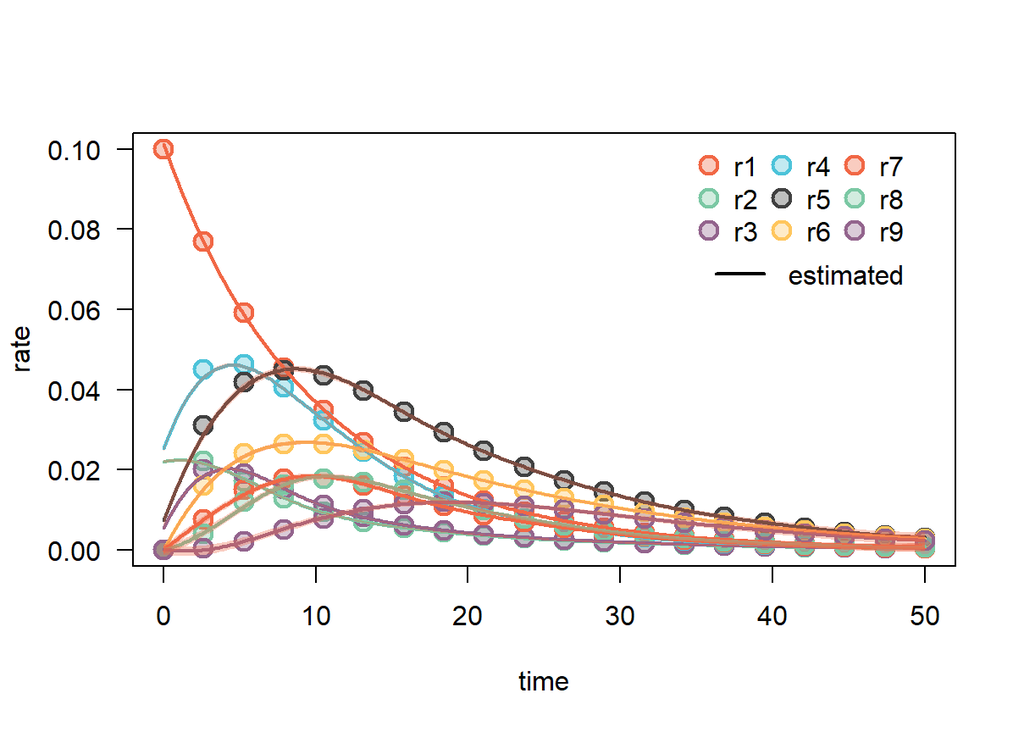

```r
# true flux values
x <- simulations$result[,1]
y <- simulations$result[,13:21]

# fluxes calculated with DynafluxR
x_sim <- res$tpp
y_sim <- res$vsp(res$tpp)
y_sim_sd_p <- res$vsp(res$tpp, fsd=1)
y_sim_sd_m <- res$vsp(res$tpp, fsd=-1)

# plot true vs estimated fluxes
matplot(x=x, y=y, type="p", pch=21, cex=1.5, lwd=2, col=col_6, bg=col_6_alpha, las=1, ylab="rate", xlab="time", ylim=c(0,0.1))
matlines(x=x_sim, y=y_sim, lwd=2, lty=1, col=col_6)

# add confidence intervals
for (i in seq(ncol(y_sim))){
  polygon(x=c(x_sim, rev(x_sim)), y=c((y_sim_sd_p[,i]), rev(y_sim_sd_m[,i])),
          col=col_6_alpha, border=NA)
}

# add legend
leg <- stringr::str_remove_all(stringr::str_remove_all(colnames(y), "]"), "Values\\[")
legend("topright", inset=c(-0.04, 0), legend=leg, col=col_6, pch=21, pt.bg=col_6_alpha, pt.cex=1.5, pt.lwd=2, bty="n", ncol=4)
legend("topright", inset=c(0.045, 0.25), legend="estimated", col="black", lwd=2, bty="n")
```

Calculate mean error on rates.

```r
mean_err_rates <- mean(as.matrix(abs(simulations$result[,13:21] - res$vsp(res$tp))))

mean_err_rates
```

```
#> [1] 0.0004883415
```

## 2.3. Robustness analysis

```r
# number of data points (from 5 to 20)
n_points <- seq(3, 20)
# number of knots (from 2 to 5)
n_k <- seq(2, 5)
# matrix to store results
residuals_k_p <- matrix(data=NA, ncol=length(n_k), nrow=length(n_points))

for (i in n_points){

  # set number of data points to simulate
  setTimeCourseSettings(intervals=i-1)

  # run time-course simulation with COPASI
  simulations <- runTimeCourse()

  # save simulated metabolite dynamics (input format of DynafluxR)
  concentrations <- simulations$result[,1:12]
  fname <- file.path(tmp_dir, "tmp_1.txt")
  write.table(concentrations, file=fname, row.names=FALSE, sep="\t", quote=FALSE)

  # for each number of knots
  for (k in n_k){

    if (k < i-1){

    # calculate fluxes with DynafluxR
    suppressWarnings({
      res <- cli(c("-m", fname,
                   "-s", file.path(example1_dir, "network.txt"),
                   "-k", k))
    })

    # calculate mean flux error
    y <- simulations$result[,13:21]
    y_sim <- res$vsp(res$tp)
    residuals_k_p[i-n_points[1]+1, k-n_k[1]+1] <- mean(as.matrix(abs(y-y_sim)))

    }
  }
}
```

Plot results.

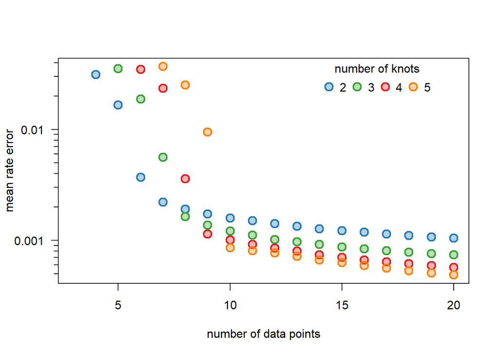

```r
matplot(x=n_points, y=residuals_k_p, ylab="mean rate error", xlab="number of data points", las=1, pch=21, col=col_pal, bg=col_pal_alpha, cex=1.5, lwd=2, yaxt="n", log="y")
axis(2, at=c(1e-3, 1e-2, 1e-1), label=c(0.001, 0.01, 0.1), las=1)
axis(2, at=c(seq(0.0002, 0.0009, by=0.0001), seq(0.002, 0.009, by=0.001), seq(0.02, 0.09, by=0.01)), labels=FALSE, tcl=-0.3)

legend("topright", inset=c(0.08, 0), title="number of knots", legend=n_k, col=col_pal, pch=21, pt.bg=col_pal_alpha, pt.cex=1.5, pt.lwd=2, bty="n", ncol=4)
```

```r
# noise levels (relative to the maximal concentration of each metabolite)
l_noise <- c(0.01, 0.02, 0.05, 0.1, 0.2)

# number of datasets to generate for each noise level
n_mc <- 100

# matrix to save calculation results
residuals_mc <- matrix(data=NA, ncol=n_mc, nrow=length(l_noise))
rownames(residuals_mc) <- l_noise

# run time-course simulation with COPASI (-> true values)
setTimeCourseSettings(intervals=99)
simulations <- runTimeCourse()
concentrations <- simulations$result[,1:12]
fluxes <- simulations$result[,13:21]

# for each noise level
for (i in seq(length(l_noise))){

  # run monte carlo analysis (n_mc iterations)
  for (j in seq(n_mc)){

    # generate noisy dataset
    sd_to_add <- apply(concentrations[-1], 2, mean)*l_noise[i]
    noise <- rnorm(prod(dim(concentrations))-nrow(concentrations), mean=0, sd=rep(sd_to_add, each=nrow(concentrations)))
    concentrations_noise <- concentrations[,-1] + matrix(noise, ncol=11)
    concentrations_noise[concentrations_noise < 0] <- 0
    concentrations_noise <- cbind(concentrations[,1], concentrations_noise)
    colnames(concentrations_noise) <- colnames(concentrations)

    # save dataset in DynafluxR format
    fname <- file.path(tmp_dir, "tmp_2.txt")
    write.table(concentrations_noise, file=fname, row.names=FALSE, sep="\t", quote = FALSE)

    # run flux calculation with DynafluxR
    res <- cli(c("-m", fname, "-s", file.path(example1_dir, "network.txt")))

    # calculate mean flux error
    residuals_mc[i,j] <- mean(as.matrix(abs(fluxes - res$vsp(res$tp))))

  }
}
```

Plot results.

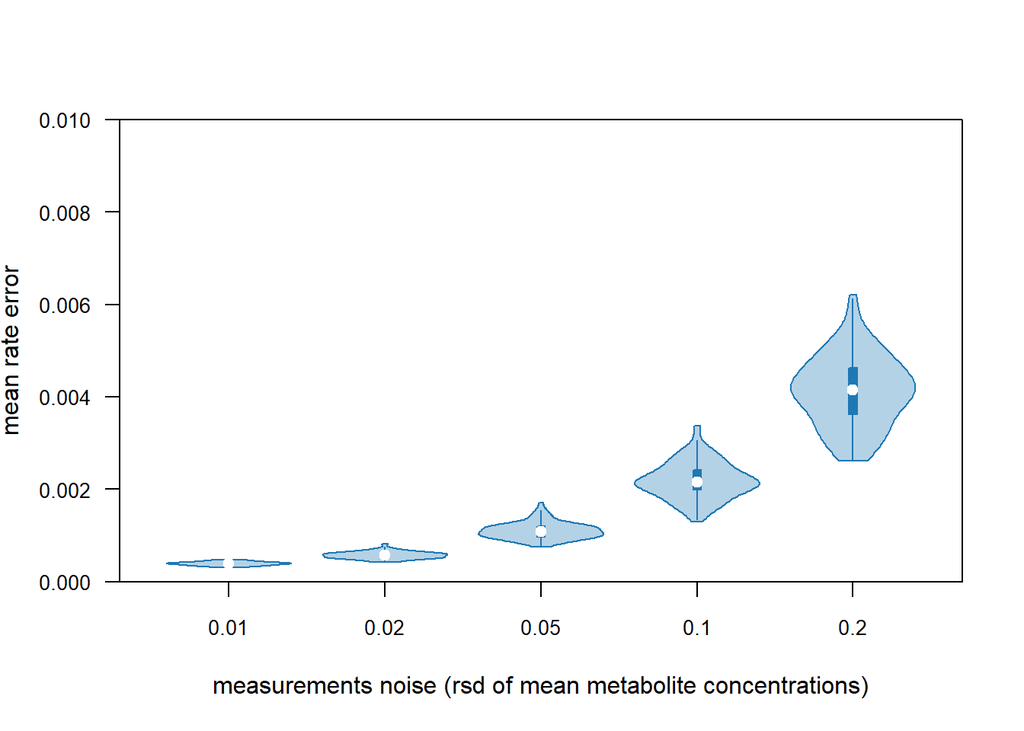

```r
# plot results
vioplot(x=t(residuals_mc), use.cols = TRUE, las=1, col="#1F78B455", border="#1F78B4", rectCol="#1F78B4", lineCol="#1F78B4", ylim=c(0, 0.01), cex.axis=0.85, yaxs="i")
title(xlab="measurements noise (rsd of mean metabolite concentrations)")
title(ylab="mean rate error", line=3.3)
```

# 3. Example 2: Real-time NMR analysis of a multi-enzymatic reaction system

Set paths.

```r
example2_dir <- file.path(wd, "multienzymatic_model")
model2_dir <- file.path(example2_dir, "kinetic_model")
```

## 3.1. Flux calculation

Calculate fluxes with DynafluxR with the following parameters:

- skip the 24 first time points that cause instabilities (`"--skip=24"`)
- force monotonic decrease of GLC, and monotonic increase of FBP (`"--decr", "GLC"` and `"--incr", "FBP"`)
- apply scaling factors to FBP and F6P since only their relative concentrations are measured (`"--sf=FBP,F6P"`)
- define standard deviation on metabolite concentrations (`"--sderr=GLC=0.05,G6P=0.05,FBP=0.1,F6P=0.05"`)

The complete list of parameters can be accessed with `cli("-h")`.

```r
startTime <- Sys.time()

res=cli(c("-m", file.path(example2_dir, "data.txt"),
          "-s", file.path(example2_dir, "network.txt"),
          '-a', file.path(example2_dir, "atom.tsv"),
          "-o", file.path(example2_dir, "flux_calculation"),
          "--decr", "GLC",
          "--incr", "FBP",
          "--skip=24",
          "--sf=FBP,F6P",
          "--sderr=GLC=0.05,G6P=0.05,FBP=0.1,F6P=0.05"))

endTime <- Sys.time()
```

Show calculation time.

```r
print(endTime - startTime)
```

```
#> Time difference of 0.479279 secs
```

Statistical evaluation of the fit.

```r
res$chi2tab
```

|  | rss | var_ref | df | chi2 | pval |
| --- | --- | --- | --- | --- | --- |
| GLC | 0.2339998 | 0.002500000 | 990 | 93.59992 | 1 |
| G6P | 0.3708691 | 0.002500000 | 990 | 148.34765 | 1 |
| F6P | 0.1402564 | 0.002821918 | 990 | 49.70250 | 1 |
| FBP | 2.6265546 | 0.009745498 | 990 | 269.51466 | 1 |
| Total | 3.3716799 | 0.017567416 | 3960 | 561.16473 | 1 |

Load measured metabolite dynamics.

```r
data <- read.table(file.path(example2_dir, "data.txt"), header=TRUE)
data
```

| Time | GLC | G6P | F6P | FBP |
| --- | --- | --- | --- | --- |
| 10.00000 | 5.539973e+00 | 0.5113790 | 0.01905308 | 0.22766398 |
| 10.66667 | 5.463889e+00 | 0.5521867 | 0.01520346 | 0.25647701 |
| 11.33333 | 5.452435e+00 | 0.6200741 | 0.02007393 | 0.22162830 |
| 12.00000 | 5.386349e+00 | 0.6650205 | 0.02677517 | 0.26174920 |
| 12.66667 | 5.409420e+00 | 0.7111662 | 0.02089481 | 0.20271974 |
| 13.33333 | 5.393365e+00 | 0.7319101 | 0.02205172 | 0.16380583 |
| 14.00000 | 5.227016e+00 | 0.7684260 | 0.02410329 | 0.15140393 |
| 14.66667 | 5.276852e+00 | 0.8476286 | 0.02600677 | 0.15506643 |
| 15.33333 | 5.171774e+00 | 0.9073741 | 0.03396923 | 0.12066418 |
| 16.00000 | 5.142935e+00 | 0.8866739 | 0.03047436 | 0.08445720 |

[output cut: 1014 more lines]

Plot measured vs fitted metabolite dynamics.

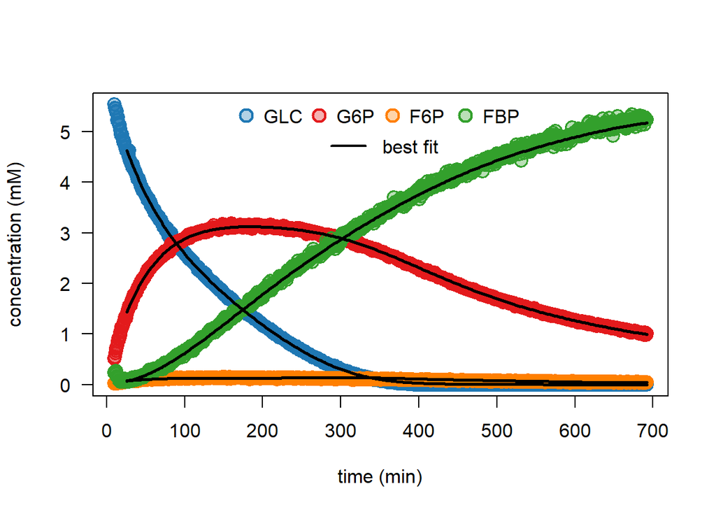

```r
col_4 <- c("#1F78B4", "#E31A1C", "#FF7F00", "#33A02C")
col_4_alpha <- paste(col_4, "55", sep="")

# plot measured metabolite dynamics
matplot(x=data[,1], y=data[,2:5], type="p", pch=21, cex=1.5, col=col_4, las=1, ylab="concentration (mM)", xlab="time (min)", lwd=1.5, bg=col_4_alpha)

# add best fit
matlines(x=res$tpp, y=res$isp(res$tpp)[,c(1,3,5,6)], lwd=2.5, lty=1, col="black")

# add legend
legend("topright", inset=c(0.24, 0), legend=colnames(data[,2:5]), col=col_4, pch=21, pt.bg=col_4_alpha, pt.cex=1.5, pt.lwd=2, bty="n", ncol=4)
legend("top", inset=c(0.18, 0.1), legend="best fit", col="black", lwd=2, bty="n")
```

Plot rate dynamics.

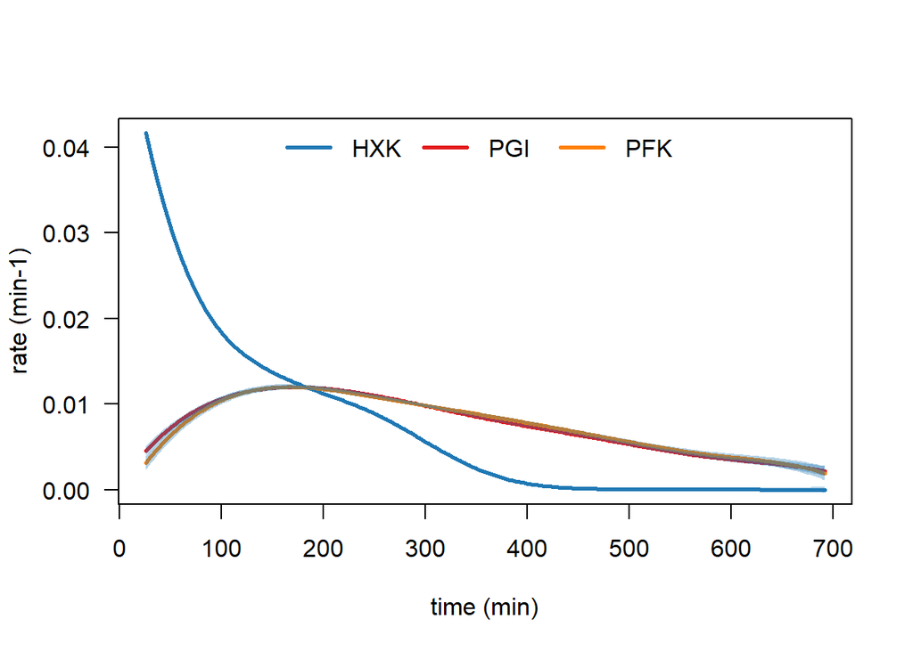

```r
# get data to plot
x_sim_full <- res$tpp
y_sim_full <- res$vsp(res$tpp)
y_sim_sd_p_full <- res$vsp(res$tpp, fsd=1)
y_sim_sd_m_full <- res$vsp(res$tpp, fsd=-1)

# plot fluxes
matplot(x=x_sim_full, y=y_sim_full, type="l", lwd=2.5, lty=1, col=col_4, las=1, ylab="rate (min-1)", xlab="time (min)")

# add confidence intervals
for (i in seq(ncol(y_sim_full))){
  polygon(x=c(x_sim_full, rev(x_sim_full)), y=c((y_sim_sd_p_full[,i]), rev(y_sim_sd_m_full[,i])),
          col=col_4_alpha, border=NA)
}

# add legend
leg <- stringr::str_remove_all(colnames(y_sim_full), ":")
legend("topright", inset=c(0.04, 0), legend=leg, col=col_4, lwd=2.5, pt.bg=col_4_alpha, cex=1, bty="n", ncol=4)
```

## 3.2. Detailed information on metabolite dynamics

The rate estimations allow us to isolate the time-resolved contribution of individual reactions on metabolite dynamics.

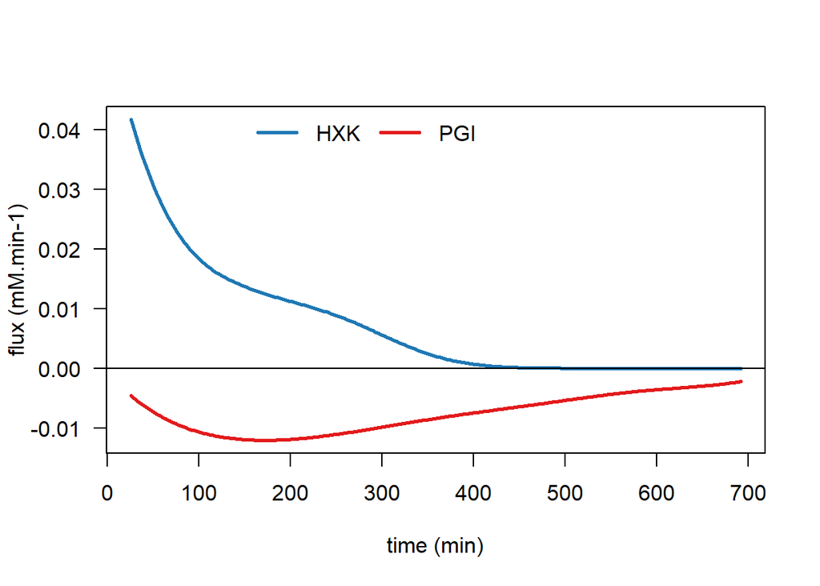

```r
x_sim <- res$tpp
y_sim <- res$vsp(res$tpp)
y_sim <- y_sim[,c("HXK:", "PGI:")]
y_sim[,"PGI:"] <- (-y_sim[,"PGI:"])

# plot fluxes
matplot(x=x_sim, y=y_sim, type="l", lwd=2.5, lty=1, col=col_4, las=1, ylab="flux (mM.min-1)", xlab="time (min)")
abline(h=0)

# add legend
leg <- stringr::str_remove_all(colnames(y_sim), ":")
legend("topright", inset=c(0.04, 0), legend=leg, col=col_4, lwd=2.5, pt.bg=col_6[1:3], cex=1, bty="n", ncol=4)
```

## 3.3. Evaluation of carbon balance

Plot carbon balance of consolidated dataset.

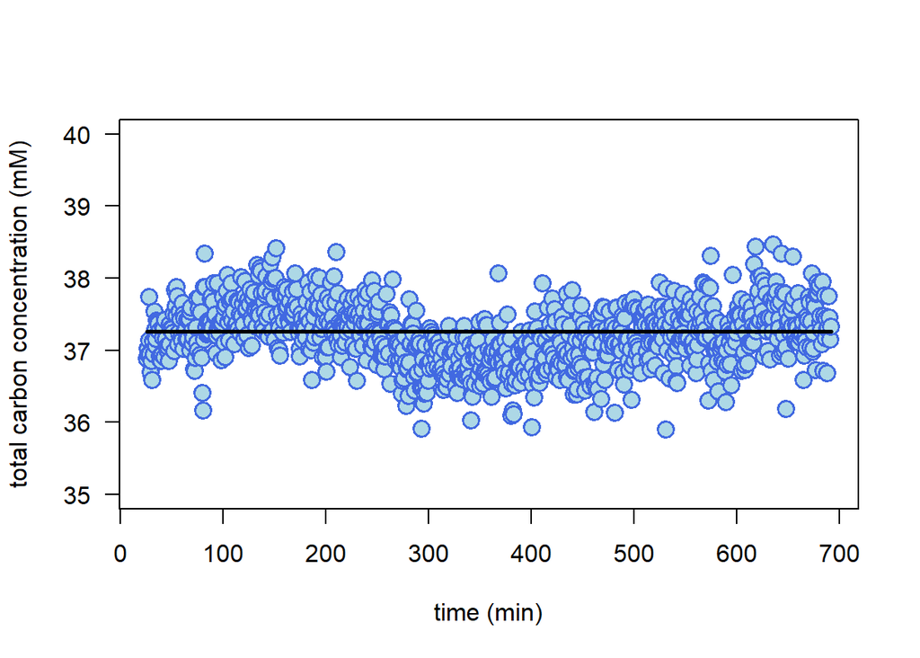

```r
# calculate carbon balance
x_sim <- res$tpp
y_sim <- res$iasp(res$tpp)
y_meas <- colSums(t(res$mf[,-1L])*res$atomlen[colnames(res$mf)[-1L]], na.rm=TRUE)

# plot measured and fitted C balance
matplot(x=res$tp, y=y_meas, type="p", pch=21, cex=1.5, lwd=1.5, bg="lightblue", col="royalblue", las=1, ylab="total carbon concentration (mM)", xlab="time (min)", ylim=c(35,40))
matlines(x=x_sim, y=y_sim, type="l", lwd=2.5, lty=1, col="black")
```

## 3.4. Prediction of FBP dynamics

```r
res=cli(c("-m", file.path(example2_dir, "data.txt"),
          "-s", file.path(example2_dir, "network.txt"),
          "-o", file.path(example2_dir, "prediction_FBP"),
          "--decr", "GLC",
          "--incr", "FBP",
          "--skip=24",
          "--lna=FBP",
          "--sderr=GLC=0.1,G6P=0.1,F6P=0.1"))
```

Plot rates estimated with and without FBP.

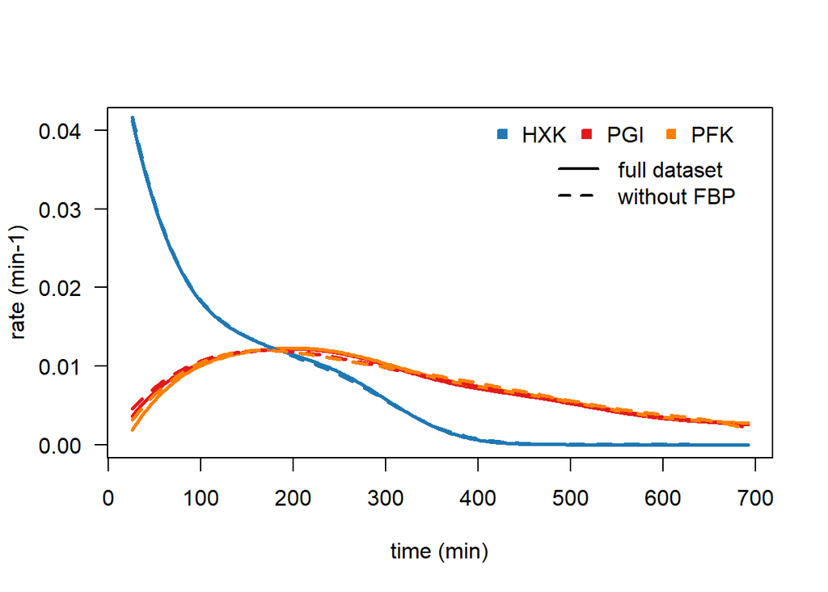

```r
# get data to plot
x_sim <- res$tpp
y_sim <- res$vsp(res$tpp)
y_sim_sd_p <- res$vsp(res$tpp, fsd=1)
y_sim_sd_m <- res$vsp(res$tpp, fsd=-1)

# plot fluxes
matplot(x=x_sim, y=y_sim, type="l", lwd=2.5, lty=1, col=col_4, las=1, ylab="rate (min-1)", xlab="time (min)")

matlines(x=x_sim_full, y=y_sim_full, type="l", lwd=2.5, lty=2, col=col_4, las=1, ylab="rate (min-1)", xlab="time (min)")

# add legend
leg <- stringr::str_remove_all(colnames(y_sim), ":")
legend("topright", inset=c(0.04, 0), legend=leg, col=col_4, pch=22, pt.bg=col_4, cex=1, bty="n", ncol=3)
legend("topright", inset=c(0.04, 0.1), lty=c(1,2), legend=c("full dataset", "without FBP"), col="black", cex=1, lwd=2, bty="n", ncol=1)
```

Predicted FBP dynamics.

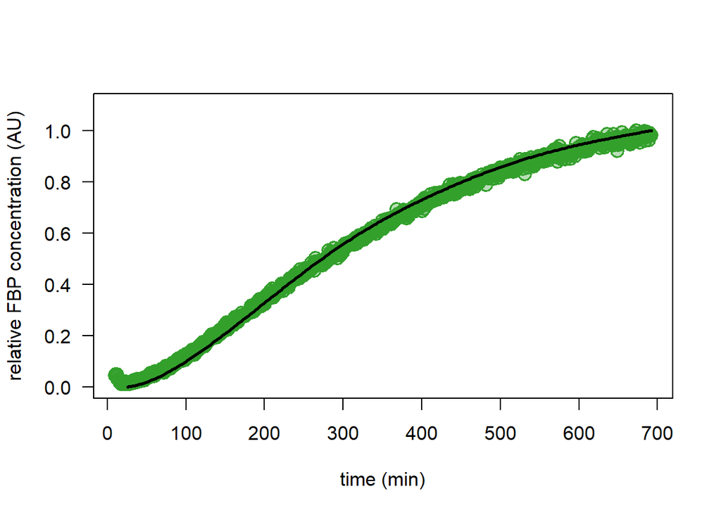

```r
x <- data$Time
FBP_meas <- data$FBP
FBP_meas_scaled <- FBP_meas/max(FBP_meas)

x_pred <- res$tpp
FBP_pred <- res$isp(res$tpp)[,"FBP"]
FBP_pred_scaled <- FBP_pred/(max(FBP_pred))


plot(x=x, y=FBP_meas_scaled, type="p", cex=1.5, lwd=1.5, las=1.5, ylab="relative FBP concentration (AU)", xlab="time (min)", ylim=c(0,1.1), pch=21, col=col_4[4], bg=col_4_alpha[4])
lines(x=x_pred, y=FBP_pred_scaled, lwd=2.5, lty=1, col="black")
```

## 3.5. Comparison with kinetic model

Load kinetic model in COPASI.

```r
# load kinetic model in COPASI
loadModel(file.path(model2_dir, "kinetic_model.cps"))
```

```
#> # A COPASI model reference:
#> Model name: "New Model"
#> Number of compartments: 1
#> Number of species: 6
#> Number of reactions: 3
```

Run parameter estimation.

```r
# run parameter estimation
par_model <- runParameterEstimation()
# display duration of parameter estimation
par_model$main$cpu_time_s
```

```
#> [1] 27.95312
```

Simulate fluxes corresponding to best fit.

```r
# run time course simulations from best fit
simulations <- runTimeCourse()
```

Compare fluxes estimated with kinetic modeling (COPASI) and stoichiometric modeling (DynafluxR).

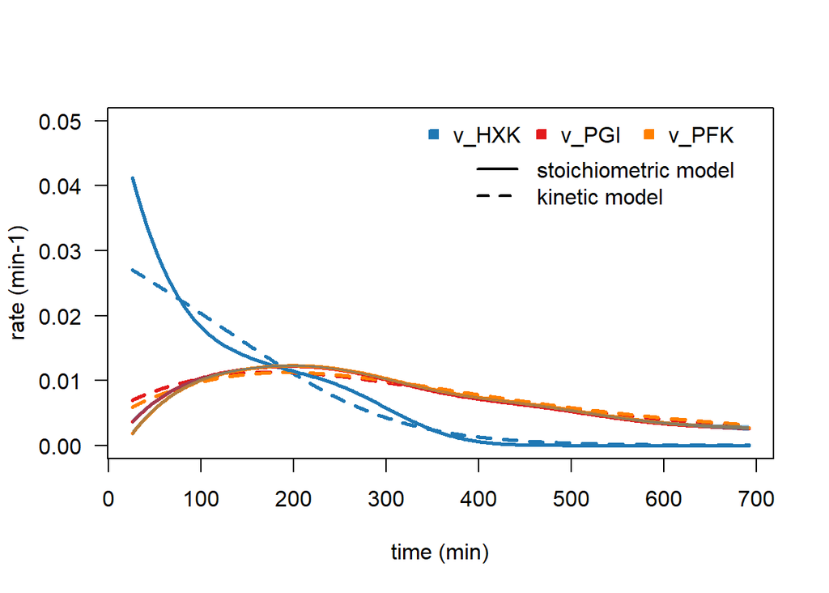

```r
# get fluxes from the best fit (COPASI)
x <- simulations$result[25:1025,1]
y <- simulations$result[25:1025,10:12]

# get fluxes from the best fit (DynafluxR)
x_sim <- res$tpp
y_sim <- res$vsp(res$tpp)
y_sim_sd_p <- res$vsp(res$tpp, fsd=1)
y_sim_sd_m <- res$vsp(res$tpp, fsd=-1)

# plot flux dynamics
matplot(x=x, y=y, type="l", lty=2, lwd=2.5, col=col_4, las=1, ylab="rate (min-1)", xlab="time (min)", ylim=c(0,0.05))
matlines(x=x_sim, y=y_sim, lwd=2.5, lty=1, col=col_4)

# add confidence intervals (DynafluxR)
for (i in seq(ncol(y_sim))){
  polygon(x=c(x_sim, rev(x_sim)), y=c((y_sim_sd_p[,i]), rev(y_sim_sd_m[,i])),
          col=col_4_alpha, border=NA)
}

# add legend
leg <- stringr::str_remove_all(stringr::str_remove_all(colnames(y), "]"), "Values\\[")
legend("topright", inset=c(0.04, 0), legend=leg, col=col_4, pch=22, pt.bg=col_4, cex=1, bty="n", ncol=3)
legend("topright", inset=c(0.04, 0.1), lty=c(1,2), legend=c("stoichiometric model", "kinetic model"), col="black", cex=1, lwd=2, bty="n", ncol=1)
```